# algorithms_helpers

- Audio-Kit Algorithms Documentation
  - Algorithms memory pool allocation
  - AcousticBF
  - CIC
    - Overview
    - Limitations
    - Inputs/Outputs
    - Configuration Parameters
  - DeInterleave
    - Overview
    - Features
    - Inputs/Outputs
    - Processing Steps
    - Configuration Parameters
  - Faust
  - fBeamforming
    - Overview
    - Features
    - Inputs/Outputs
    - Processing Steps
    - Configuration Parameters
    - How to update the parameters
  - fdisjoin
    - Overview
    - Features
    - Inputs/Outputs
    - Processing Steps
    - Configuration Parameters
  - FIR equalizer
    - Configuration Parameters
    - How to add a point in the firResponseCurve curve
    - WARNING: known limitation
  - FIR graphic equalizer
    - Configuration Parameters
    - WARNING: known limitation
  - fjoin
    - Overview
    - Features
    - Inputs/Outputs
    - Processing Steps
    - Configuration Parameters
  - fnlms
    - Overview
    - Inputs/Outputs
  - G711dec
    - Features
    - Inputs/Outputs
    - Processing Steps
    - Configuration Parameters
  - G711Enc
    - Features
    - Inputs/Outputs
    - Processing Steps
    - Configuration Parameters
  - HPF
  - IIR equalizer
  - Interleave
    - Overview
    - Features
    - Inputs/Outputs
    - Processing Steps
    - Configuration Parameters
  - Linear mix
    - Overview
  - MDRC
    - How to add a point in the dynamicResponse curve
  - Mix
    - Overview
    - Features
    - Inputs/Outputs
    - Processing Steps
    - Configuration Parameters
  - Mono2Stereo
    - Features
    - Inputs/Outputs
    - Processing Steps
    - Configuration Parameters
  - NLMS
    - Overview
    - Inputs/Outputs
  - NR
  - PDM2PCM
    - Features
    - Inputs/Outputs
    - Processing Steps
    - Configuration Parameters
  - Resample
    - Overview
    - Features
    - Inputs/Outputs
    - Processing Information
    - Configuration Parameters
  - Route
    - Overview
    - Features
    - Inputs/Outputs
    - Processing Steps
    - Configuration Parameters
    - Usage Example and Hints
  - Sam
    - Overview
    - Features
    - Inputs/Outputs
    - Configuration Parameters
    - Control API - SAM Tuning
  - SFC
    - Overview
    - Features
    - Inputs/Outputs
    - Configuration Parameters
  - Sound-font
    - Sound-font description.
  - Split
    - Overview
    - Features
    - Inputs/Outputs
    - Processing Steps
    - Configuration Parameters
  - Stereo2Mono
    - Features
    - Inputs/Outputs
    - Processing Steps
    - Configuration Parameters
  - WOLA
    - Overview
    - Features
    - Inputs/Outputs
    - Processing Steps
    - Configuration Parameters
  - Message Viewer

# Audio-Kit Algorithms Documentation

This document hosts documentation of algorithms.

## Algorithms memory pool allocation

In addition to the algorithm parameters described below, a new parameter called `ramType` has been added. This parameter allows you to choose the preferred memory pool for most algorithms, especially those that consume a lot of memory or for which the memory type significantly impacts CPU load. The available memory pools are:

- **Tightly Coupled Memory (TCM)**: The fastest memory.
- **Internal RAM**: Medium performance memory.
- **External RAM**: The largest memory, if present.

The algorithm’s memory allocator will first attempt to allocate memory in the specified pool. If the requested memory pool is unavailable (due to platform limitations or insufficient remaining memory), it will fall back to another memory pool.

When an audio design is running, the `mem2` command displays the detailed memory consumption for each algorithm in each memory pool, indicating where memory allocation was requested and where it was actually allocated.

Note: Each algorithm has a ‘generic’ memory part (for handle, config, etc.) and a ‘specific’ memory part (e.g., internal audio buffers or any other memory needed for processing). The `ramType` parameter only affects the allocation of the ‘specific’ memory part. In order to change the pool of the ‘generic’ please refer to this chapter.

## AcousticBF

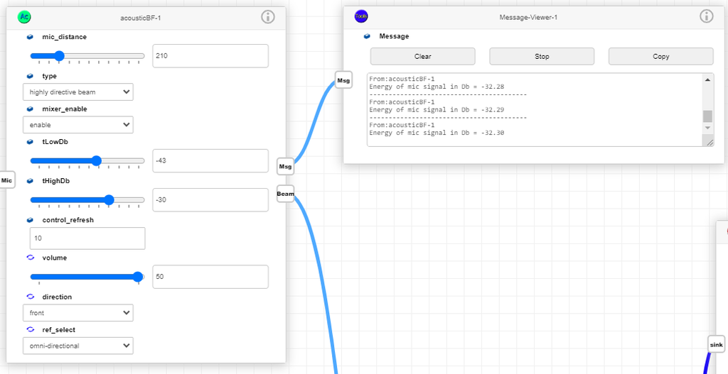

The AcousticBF software library is fully described in the documentation called “AcousticBF_Library.chm” located inside the folder:

Middlewares/ST/STM32_Audio/STM32_AcousticBF_Library/Documentation of the package.

However, the AudioChain wrapper adds a feature called “Mixer” that can be enabled from the parameter mixer_enable. This feature allows to mix the output of the highly directive beamforming with one of the input microphones signals.

It is functional with both presets called ACOUSTIC_BF_TYPE_STRONG & ACOUSTIC_BF_TYPE_ASR_READY. It doesn’t work with presets called ACOUSTIC_BF_TYPE_CARDIOID_DENOISE & ACOUSTIC_BF_TYPE_CARDIOID_BASIC**.**

Two parameters need to be tuned when activated:

1. tLowDb: Low threshold for mixing with omni microphone. If level is inferior to this threshold, then only omni microphone in output signal. Unit is dB.
2. tHighDb: High threshold for mixing with omni microphone. If level is superior to this threshold, then only processed data in output signal. Unit is dB.
- In between both thresholds, a linear gain is applied as function of the energy of the first raw microphone signal.
- To tune it, please do as follow:
  - Connect a message viewer to the “Msg” output pin,
  - Set the control_refresh to a value higher than 1 (it is counting the number of frames before refreshing the control data),
  - Run the device in the sound environment it should support and set the thresholds as function of the value measured.

## CIC

[figure not shown]

### Overview

The CIC (Cascaded Integrator-Comb) module is designed to perform decimation of Pulse Density Modulation (PDM) input streams to Pulse Code Modulation (PCM) output streams. The module supports multi-channel interleaved PDM input and produces interleaved PCM output. The decimation ratio is an integer value, and the input sampling frequency divided by the output sampling frequency multiplied by 8 must be an integer value.

### Limitations

- **Sampling Frequency Ratio**: The ratio of input sampling frequency to output sampling frequency is an integer value.
- **Decimation**: Decimation is performed by accumulation of byte packets, ensuring that the input sampling frequency divided by the output sampling frequency multiplied by 8 is an integer value.
- **SINC order**: up to 5

### Inputs/Outputs

- **Input Stream**:
  - A single audio input stream.
  - Accepts only PDM (LSB first or MSB first) format with multi-channel interleaved by bytes.
  - Supports all PDM frequencies allowed by AudioChain.
- **order**:
  - SINC filter order. Maximum is 5
- **rbs**:
  - Right bit shift of the output samples.
  - Helps to guarantee no saturation in case of 16-bit samples
  - Can be used as a gain control if saturation is allowed.

#### Output

- **Output Stream**:
  - A single audio output stream.
  - Produces PCM output in int16 or int32 format
  - In case of multichannel, data is interleaved.
  - ratio of input and output sampling frequency must be an integer value.
  - Ensure that the input sampling frequency divided by the output sampling frequency multiplied by 8 is an integer value (fsIn / (fsOut * 8) ).

### Configuration Parameters

There are two types of parameters:

1. Format information for conversion retrieved from the input and output pins:
   - sampling frequency
   - number of channels
   - PDM format (MSB or LSB)
   - PCM format (int16 or int32)
2. Configuration parameters:
   - SINC filter order
   - right bit shift of the output samples

## DeInterleave

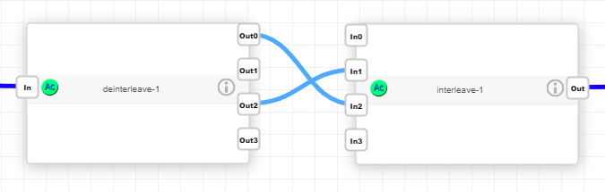

### Overview

This document outlines the specifications for an audio processing block that deinterleaves an input stream into a several output streams. The output streams will contain all requested channels from the input stream.

Please note that the primary function of this algorithm is to split a single multichannel input stream into several output streams. It is not designed to alter the interleaving format of the individual samples within the stream; such transformations are the responsibility of the “SFC” (Sample Format Conversion) algorithm.

### Features

- **Multiple Outputs**: Generate several audio output streams from a single input.
- **Channel selection**: Supports output streams with different number of channels.
- **Deinterleaving**: interleaved inputs into several output streams.
- **Format conversion**: Ability to change data format thanks to the SFC algorithm.

### Inputs/Outputs

- **Input Stream**: Single audio multichannel input stream.
- **Source Format**: The current format of the input audio samples is known thanks to the input pin that is aware of its own properties including data type and interleaving (see SFC documentation).
- **Target Format**: The desired format for the output audio samples is known thanks to the output pins that are aware of their own properties data type and interleaving (SFC documentation).

#### Output

- **Interleaved Audio Streams**: Several output streams with different number of channels; the sum of number of channels of output streams must be equal to the number of channels of input stream.

### Processing Steps

Note: this algorithm encapsulates the SFC for input & output management. Please refer to its documentation.

1. **Input Handling**: The block receives audio from an input multichannel stream.
2. **Deinterleaving** & **format conversion**:
- Channels from the input stream are extracted and copied into the different output streams as requested. Channels selection is done while setting the output pins characteristics.
- Note: Before the initialization phase, the consistency checks of the algorithm checks that the number of input channels is equal to the sum of all output streams channels.
- Deinterleave supports following format conversion:
  1. interleaved into non interleaved sample and vice versa.
  2. Can convert from any of this data type to any other within this list: FIXED16, FIXED32, FLOAT, G711.
  3. Can convert input PDM LSB into PDM MSB and vice versa.
- Deinterleave doesn’t support the following format conversion:
  1. It cannot convert PCM to PDM data nor PDM into PCM data (see PDM2PCM algorithm for that).
  2. It cannot convert sampling frequency.
1. **Output Generation**:
- The final output streams are produced with all channels from the input.

### Configuration Parameters

The setting of the format conversion is handled by tuning the input & output pins according to the desired characteristics. Please refer to the SFC documentation.

The setting of deinterleaving is also done thru the input and output pins as shown by following figure.

In the example below, the input stream has 3 channels deinterleaved into two streams:

- The first output has 2 channels.
- The second output has a single channel.
- We could also have created three mono output streams.

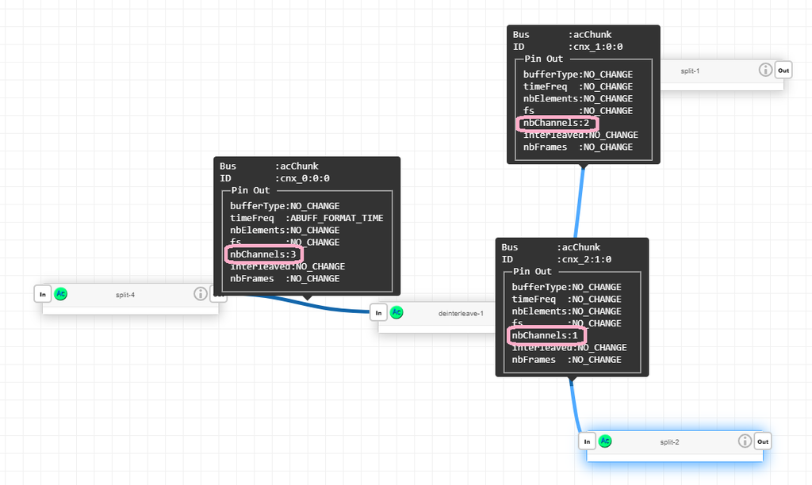

## Faust

Faust algorithms integration in audio-kit.

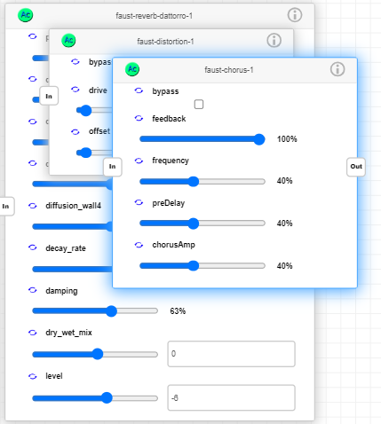

**Faust description**

Faust (Functional Audio Stream) is a programming language specifically designed for real-time signal processing and synthesis. Faust is used to create audio applications and plugins for various platforms and standards. The Faust IDE (Integrated Development Environment) is a tool that provides a user-friendly interface for writing, compiling, and testing Faust code. You can build your audio stream programmatically or using the link at https://faustide.grame.fr.

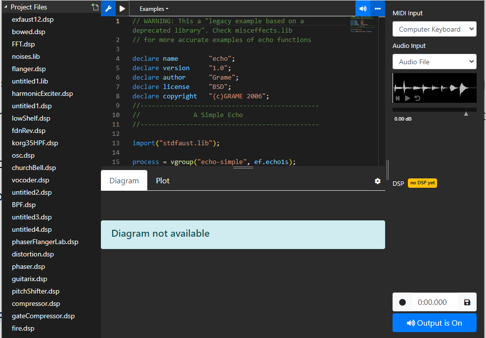

**Audio Kit Conversion**

Audio Kit can integrate automatic Faust design directly from the .dsp (Faust project). The resource takes place in the folder Middlewares/ST/Audio-Kit/tools/faust. All you need is a .c file generated by the Faust application.

There are two ways to create a Faust Element

Using Web interface:

- Design your effect on the website :
- Export the C file! select “export -> source -> C”.

Using Faust command line interface and the DSP file.

- You can create a .dsp from the faust code editor by copy/past
- Download Faust Cli from https://github.com/grame-cncm/faust/releases.

Faust2AC.py is a python file that automatically converts a Faust-ide-c file into an audio kit element.

The tool generates a series of source code you can integrate directly in your project.

In livetune, you will have the same tuning interface and audio will produce the same effect, excepted, that the code will run in the MCU and not on PC

The Faust2AC.py converter is given as an example. It applies some patches on the C code generated by Faust to prevent build issues and generate a glue code.

**Limitations**

However, there may be issues during the conversion due to bugs in the C generation such as:

- Syntax incompatibility with the IAR or GCC toolchain that needs manual correction,
- the converter has been tested with FAUST Version 2.70.3; later ones may come with incompatibilities
- Huge tables generated that don’t fit MCU Memory and Flash specifications, or CPU load not compatible with the MCU specifications.
- Faust generates a C file with missing headers C (Includes)
- Faust generated code may consume CPU load not compatible with the MCU specifications. The user MUST ensure that the use case is compatible with the MCU performance.

**Elements demo pre-built:**

As examples, all algorithms located inside Middlewares/ST/Audio-Kit/tools/faust have been converted directly from examples available on Faust IDE website. There are:

- phasing/phaser.dsp
- phasing/flager.dsp
- reverb/dattorro.dsp
- dynamic/compressor.dsp
- and so on

Note that the converter uses source code templates designed for filtering, which is the main use case. In this case there is only one input and one output pin. Default templates are not suitable for source elements (no input pin) or Sink elements (no output pin). Therefore, some adaptation must be done in capability descriptions to be perfectly adapted. For example, if a wave generator is designed and needs to play immediately without modifying the source code templates, the input must be connected to a dummy source element to make the audio chain engine coherencies happy. Please refer to myFaust.livetune in the folder faut for more information.

## fBeamforming

Frequency beamformer

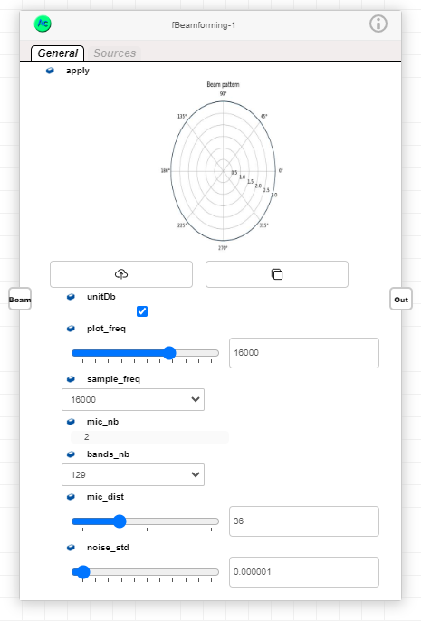

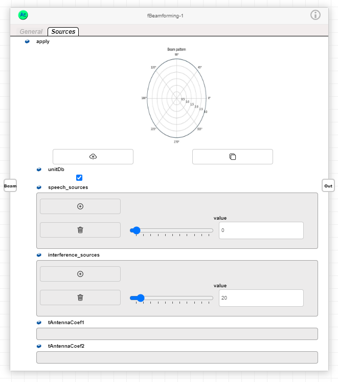

.

### Overview

This document describes a beamformer that performs processing in the frequency domain.

Beamforming is a signal processing technique used in sensor arrays for directional signal transmission or reception. This spatial filtering process can enhance the signal-to-interference ratio (SIR), which is the power ratio between a signal of interest and given interference signals.

### Features

This precise beamformer is called Maximum SIR (Signal to Interference Ratio) beamformer. It is forming beam pattern (or lobes) from different parameters such as:

- Number of sensors
  - Currently limited to two because the HW available supports 2 microphones.
  - If > 2 Supposed to be linear array.
- Distance between sensors.
- Number of bands.
- a given location of the source of interest.
- a given positions of potential interferences.
- Note: In dynamic environments, where the direction of the desired signal or interference may change, adaptive beamforming algorithms could be used, however it is not the case here. The setting is fixed at the initialization phase.

### Inputs/Outputs

- **Input Stream**: Two microphones’ data streams in the frequency domain.
- **Parameters**: See the chapter called Configuration Parameters

#### Output

- **Output Stream**: two opposite antennas in the frequency domain.

### Processing Steps

The computation of the beamformer weight is done at the initialization phase. It is a script running on a server that processes the weights from the chosen parameters. Then these weights are loaded on the STM32 flash memory to run the beamformer.

On STM32 side, the processing is:

- ant1 = mic1 * sirBeamformCoeff_1 + mic2 * sirBeamformCoeff_2
- ant2 = mic1 * sirBeamformCoeff_2 + mic2 * sirBeamformCoeff_1 for the opposite antenna (second channel)

### Configuration Parameters

There are two types of parameters:

- Input & output streams configuration:
  - Since it is in the frequency domain, there are some constraints to respect. These constraints are detailed inside both WolaFwd & WolaInv algorithms in the chapter called Frequency domain constraints in AudioChain/LiveTune
- The parameters in the UI:
  - These parameters are the one of a python script that run on a server (either local or distant) which can be set from the “preference” icon in LiveTune.
  - Part of the parameters are just for analysis such as:
    - uintDb check box.
    - plot_freq which allows to plot the shape of the pattern for a given frequency.
- Part of the parameters are fixed by the firmware:
  - Mic_nb = 2 because the setup proposed by this package only supports 2 microphone arrays.
  - Bands_nb must be tuned accordingly to the Input & output streams configuration.
- The parameters that will impact the beam pattern are:
  - In the “General” tab:
    - Mic_dist expressed in millimeters.
    - Noise_std which is the standard deviation of the background noise inside each sensor.
  - In the “Sources” tab:
    - The angle value in degrees for the source to point at.
    - The angle value in degrees for the interference where to design a 0.
    - Of course, with a two microphones array, it is useless use many sources or interferences inputs.

When a graph is done and the fBeamforming is properly connected, click the upload button to process the beamformer weights. Hit the start button in LiveTune and give it a try !

To analyze the beam pattern as function of the frequency (see previous figure):

- Please change the frequency value with the plot_freq slider.
- Hit the upload button again.
- It will generate a request to the server that hosts the script.
- The beam pattern is updated.

### How to update the parameters

1. Set the preferences in LiveTune so that the local server is used as depicted below:

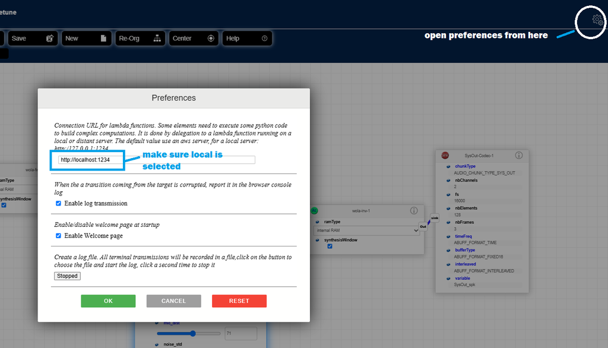

2. Under the tool folder, please run the script called `runServer.sh`.
3. In LiveTune, update the fbeamforming parameter as needed and then hit the Upload icon.

In order to update the cardoid plot, please hit the upload icon again after any parameter update.

## fdisjoin

Frequency band extraction; opposite operation is fjoin.

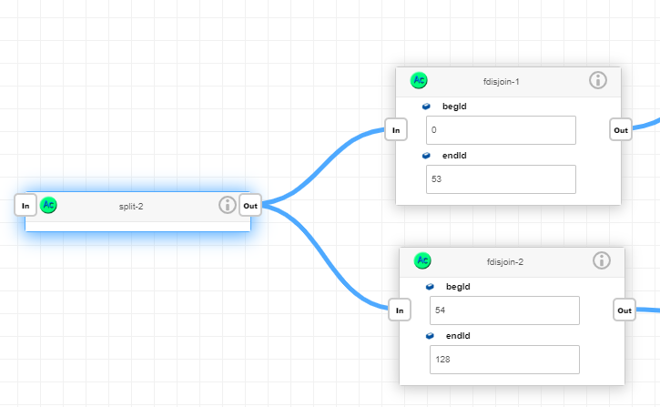

.

### Overview

This document details the functionality of an audio processing block designed to operate on audio data that is already in the frequency domain. The block’s purpose is to split a single frequency-domain input stream into several outputs, each containing a specified frequency bands range. This is ideal for applications that require parallel processing of different frequency ranges, such as multiband dynamics processing or frequency-dependent effects routing.

*Note: AudioChain frequency domain processing only supports non interleaved floating points data.*

### Features

- **Frequency-Domain Input**: Input data that is already in the frequency domain given a set of frequency sub bands.
- **Frequency-Domain Outputs**: Splits the input into multiple outputs, each with a designated set of frequency sub bands range.
- **Customizable Band Ranges**: User can define the frequency ranges for each output.
- **Transparent Processing**: Ensures no additional transformation or distortion of the frequency-domain data.

### Inputs/Outputs

- **Input Stream**: Single multiband audio stream, each potentially with multiple channels.
- **Output Bands Range indexes:** indexes of the lower and higher bands to deliver in the output stream.

#### Output

- **Output Streams**: Multiple multiband output streams, each containing a specific frequency sub bands range from the input stream.

### Processing Steps

- **Input Reception**: The block receives the frequency-domain audio stream. It has a given number of bands given by the field called “nbElements” from the input pin.
- **Band Extraction**:
  - The data corresponding to each frequency from the specified bands range is copied from the input stream to the proper output stream. The specified frequency indexes must not exceed the input stream bands indexes.

### Configuration Parameters

The **Customizable Band Ranges** are set using both parameters:

1. **begId**: index of the first band to extract
2. **endId**: index of the last band to extract
- However, the output stream (acChunk) must be configured accordingly; the nbElements must be equal to (endId -begId +1).

## FIR equalizer

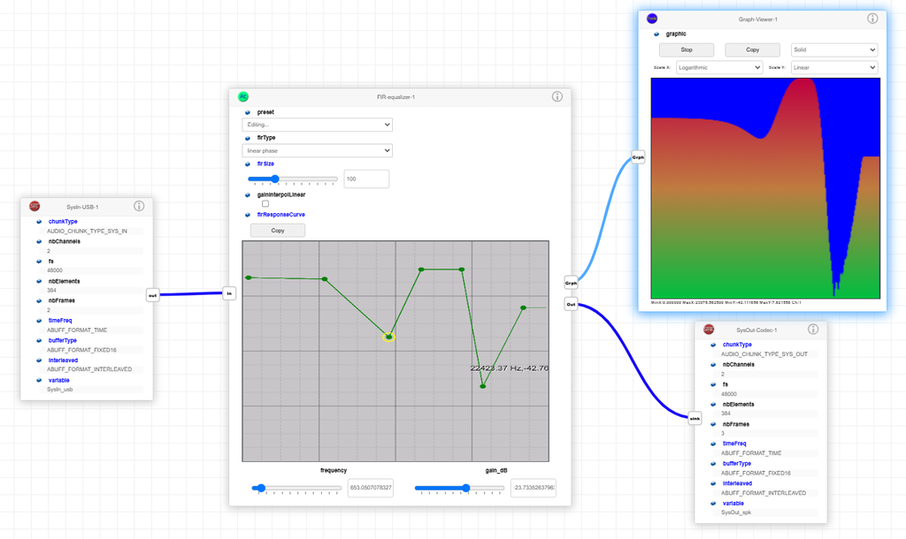

### Configuration Parameters

- **preset**:
  - FIR equalizer has several presets:
    - Acoustic - Folk,
    - Classic,
    - Electronic,
    - Hip Hop,
    - Pop,
    - Rock.
- **firType**:
  - linear phase: filter is symmetric; all frequencies are delayed with the same value (firSize/2 samples); best for music signals.
  - minimum phase: filter is not symmetric; delay is minimum but different for each frequency.
- **firSize**:
  - the bigger, the more accurate.
  - the smaller, the less memory & MHz consumption.
- **gainInterpolLinear**:
  - enabled: response curve interpolation between successive points is linear.
  - disabled: response curve interpolation between successive points is linear in dB.
- **firResponseCurve**:
  - User sets filter frequency response
  - Frequency (Hz) in abscissa (log scale), gain (dB) in ordinate,
  - When a point is selected, the user can set an accurate numerical value using frequency/gain_dB boxes below the graph.
  - Remark: the button allows to copy the **firResponseCurve** graph as an image.

### How to add a point in the firResponseCurve curve

Adding a point in the graph is done by shift click on the curve followed by a pointer move (i.e move the mouse).

“Grph” output pin may be connected to a “Graph-Viewer” to show theoretical response curve (only when audio is started); it permits for instance to see impact of firType, firSize or gainInterpolLinear (without changing any other parameter) on theoretical response curve accuracy.

### WARNING: known limitation

Filter coefficients computation from firResponseCurve consumes a lot of CPU load; thus if user updates filter configuration while the data-flow is running, this processing is shared between successive audio frames so that it consumes around 10% of the max CPU load to leave CPU power to other algos and thus to limit audio data flow issues (underrun/overrun).

Nevertheless, if audio data flow issues appear and remain persistent after FIR-equalizer reinitialization, the workaround is to stop the graph and start it again (or to update FIR-equalizer configuration while the graph is not started).

This CPU load is proportional to firSize and is much bigger for “minimum phase” than for “linear phase” firType; thus the worst case is for maximum firSize and “minimum phase” firType and may last several seconds during which the FIR-equalizer continues to apply old config.

## FIR graphic equalizer

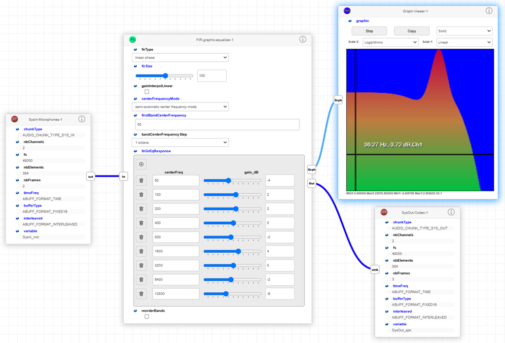

### Configuration Parameters

- **firType**:
  - linear phase: filter is symmetric; all frequencies are delayed with the same value (firSize/2 samples); best for music signals.
  - minimum phase: filter is not symmetric; delay is minimum but different for each frequency.
- **firSize**:
  - the bigger, the more accurate.
  - the smaller, the less memory & MHz consumption.
- **gainInterpolLinear**:
  - enabled: response curve interpolation between successive points is linear.
  - disabled: response curve interpolation between successive points is linear in dB.
- **centerFrequencyMode**:
  - full-automatic center frequency mode: algorithm finds automatically center frequency for every band depending on sampling frequency and number of bands (firstBandCenterFrequency and bandCenterFrequencyStep parameters are not used)
  - semi-automatic center frequency mode: algorithm computes center frequency for every band depending on firstBandCenterFrequency, bandCenterFrequencyStep and number of bands.
  - manual center frequency mode: user sets himself center frequency for every band.

WARNING: in full or semi-automatic mode, when audio is started, center frequencies are sent by FW to LiveTune and thus FW computed values are updated into the graph; when audio is not started, center frequencies are not updated into the graph because audio FW is not running but they will be updated as soon as user will start audio.

- **firstBandCenterFrequency**:
  - center frequency of the first band (used only in “semi-automatic center frequency mode”)
  - this parameter is updated automatically by audio FW in “full-automatic center frequency mode”
- **bandCenterFrequencyStep**:
  - center frequency step in octave unit between 2 successive bands (used only in “semi-automatic center frequency mode”)
  - this parameter is updated automatically by audio FW in “full-automatic center frequency mode”
- **firGrEqResponse**:
  - Click on button to add a new band, click on to remove a band.
  - in “manual center frequency mode”, user must set centerFreq value for each band (in automatic modes, it is done automatically by audio FW)
  - in all modes, user must set gain_dB value for each band
- **reorderBands**: this check box has no impact in automatic modes (because center frequencies are already correctly ordered by audio FW); in “manual center frequency mode”, this check box reorders center frequencies in ascending order

“Grph” output pin may be connected to a “Graph-Viewer” to show theoretical response curve (only when audio is started); it permits for instance to see impact of firType, firSize or gainInterpolLinear (without changing any other parameter) on theoretical response curve accuracy.

### WARNING: known limitation

Filter coefficients computation from firResponseCurve consumes a lot of CPU load; thus if user updates filter configuration while the data-flow is running, this processing is shared between successive audio frames so that it consumes around 10% of the max CPU load to leave CPU power to other algos and thus to limit audio data flow issues (underrun/overrun).

Nevertheless, if audio data flow issues appear and remain persistent after FIR-graphic-equalizer reinitialization, the workaround is to stop the graph and start it again (or to update FIR-graphic-equalizer configuration while the graph is not started).

This CPU load is proportional to firSize and is much bigger for “minimum phase” than for “linear phase” firType; thus the worst case is for maximum firSize and “minimum phase” firType and may last several seconds during which the FIR-graphic-equalizer continues to apply old config.

## fjoin

Frequency band concatenation; opposite operation is fdisjoin.

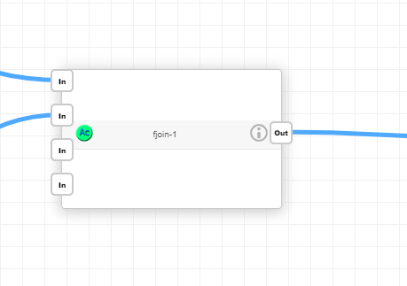

.

### Overview

This document describes an audio processing block that concatenates multiple frequency-domain input streams into a single output stream. Each input stream represents a distinct frequency band range, and the FJOIN block combines these bands to form a wider frequency spectrum in the output. This block is essential for applications that involve parallel frequency band processing and require recombination into a full-spectrum signal.

*Note: AudioChain frequency domain processing only supports non interleaved floating points data.*

### Features

- **Frequency-Domain Inputs**: Input data streams that are already in the frequency domain and which shouldn’t include full spectrum.
- **Frequency-Domain Output**: Single output stream that will receive the bands ranges concatenated.
- **Band Ranges Concatenation**: All the input bands are joined into the single output.
- **Transparent Processing**: Ensures no additional transformation or distortion of the frequency-domain data.

### Inputs/Outputs

- **Input Streams**: Multiple multiband audio stream, each potentially with multiple channels. The order of connection is important, the low bands should be connected first whereas the higher ones should be connected to the latest pins.

#### Output

- **Output Stream**: Single multiband output stream containing all the band ranges concatenated.

### Processing Steps

- **Input Reception**: The block receives multiple frequency-domain input streams, each representing a different frequency bands range.
- **Bands Concatenation**:
  - The full set of frequency bands from the input streams are recombined by order of the input pins. In other words:
    - Let’s call **Stream0** the stream connected to pin0, **Stream1** the stream connected to pin1 and so on.
    - Let’s call **StreamOut** the output stream.
    - The bands from **Stream0** are copied to the lowest bands of **StreamOut** starting from the index 0.
    - Then the bands **Stream1** are copied to the following bands of **StreamOut** starting from the index equal to **Stream0** number of bands.
    - And so on… .

### Configuration Parameters

There is no need for parameters. However, the total number of all input streams bands MUST BE equal to the output stream number of bands. Flowwoing figure provides an example:

- The acChunk stream connected to fjoin pin0 has 54 bands.
- The acChunk stream connected to fjoin pin1 has 75 bands.
- The acChunk stream connected to fjoin output pin has 129 bands.
- 54+75 = 129! It’s all fine
- However, to create an output stream with a consistent spectrum, the user must take good care of the order of connection otherwise the output signal will be wrong.

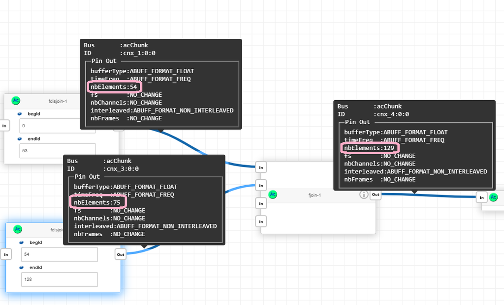

.

## fnlms

Frequency Normalized-LMS

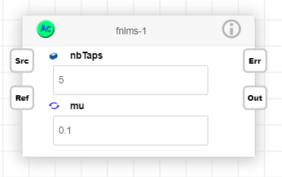

### Overview

This document describes a frequency domain version of the Normalized-LMS algorithm provided in **LiveTune**. It finds the best FIR filter, so that filtered input matches the reference signal. The process used is the minimization of Least Mean Squares of (Ref - filtered Src). Each sub band has its own adaptive filtering.

### Inputs/Outputs

- **Src**: input data.
- **Ref**: reference data
- **Number of Coefficients/taps**: It corresponds to the maximal removable echo. echo_length = numTaps / sampling_frequency;
- **Adaptation Step size**: It is the step size that controls filter coefficient updates; the biggest, the fastest convergence but the less accurate.

#### Output

- **Out**: output data:
  - It is the filtered input signal.
- **Err**: error data
  - It is the (Reference signal – filtered input signal).

## G711dec

G711 decoder

### Features

- **Input**: Accepts G711_ALAW & G711_MULAUW PCM format.
- **Output**: Accepts only fixed-point 16 bits PCM format
- **Format conversion**: Ability to change data format.

### Inputs/Outputs

- **Input Stream**: A single audio input stream.
- **Source Format**: The format for the input audio samples is known thanks to the input pin that is aware of its own properties including data type (G711 A-law or G711 mu-law) and interleaving.

#### Output

- **Output Stream**: A single audio output stream.

### Processing Steps

1. **Input Handling**: input stream is received by the audio processing block.
2. **G711 decoding**:
   1. decoding according to input data type.

### Configuration Parameters

- Format information for conversion is retrieved from the pins so that it is up to the user to configure the wires according to his desire (input data type).

## G711Enc

G711 encoder

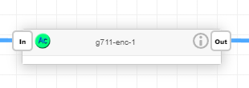

### Features

- **Input**: Accepts only fixed-point 16 bits PCM format.
- **Output**: Accepts G711_ALAW & G711_MULAUW PCM format
- **Format conversion**: Ability to change data format.

### Inputs/Outputs

- **Input Stream**: A single audio input stream.
- **Target Format**: The desired format for the output audio samples is known thanks to the output pin that is aware of its own properties including data type (G711 A-law or G711 mu-law) and interleaving.

#### Output

- **Output Stream**: A single audio output stream.

### Processing Steps

1. **Input Handling**: input stream is received by the audio processing block.
2. **G711 encoding**:
   1. Encoding according to output data type.

### Configuration Parameters

- Format information for conversion is retrieved from the pins so that it is up to the user to configure the wires according to his desire (output data type).

## HPF

High-pass filtering

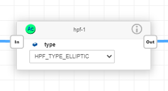

.

hpf aim is to remove DC component of audio signal; DC may appear with some microphone inputs and may impact some algo’s behavior, thus it may be necessary to remove this DC component from input signal.

The only hpf configuration parameter is the filter type; hpf uses high-pass filters and several banks of filter with different filter design methods have been included in resample algo, each of these design methods have its pro & cons in terms of MHz/memory consumption (decreasing consumption order: butterworth, chebyshev1/chebyshev2, elliptic), response curve (see https://en.wikibooks.org/wiki/Signals_and_Systems/Filter_Implementations and https://en.wikipedia.org/wiki/Elliptic_filter for more details).

All these internal filters have been designed with the following constraints:

- stop frequency: 50 Hz
- pass frequency: 200 Hz
- band-pass ripple: +/- 0.10 dB (i.e. all input signal > 200 Hz will have a gain between -0.1 and +0.1 dB)
- band-stop ripple: -60.00 dB (i.e. all input signal < 50 Hz will have a gain < -60 dB)

## IIR equalizer

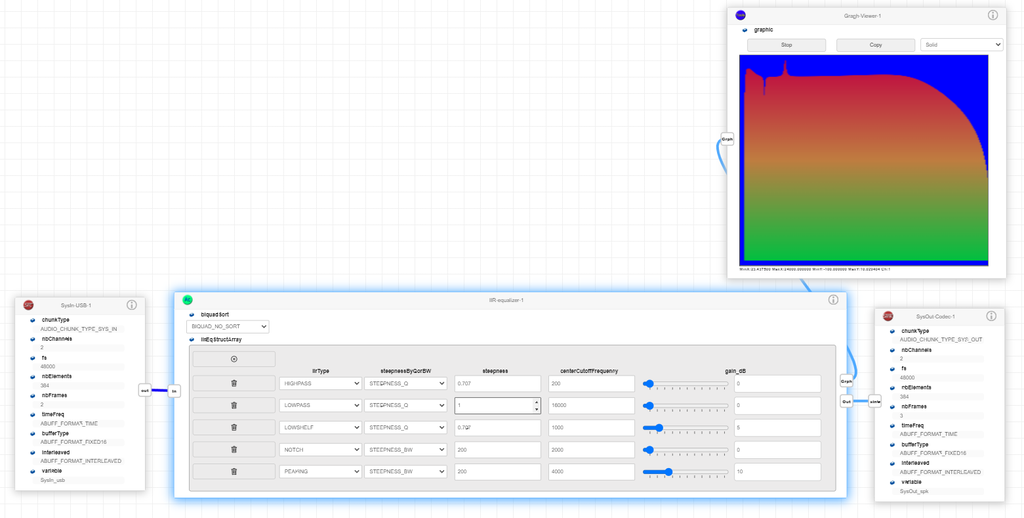

See https://webaudio.github.io/Audio-EQ-Cookbook/audio-eq-cookbook.html for IIR filter formula description.

Click on button to add a new biquad (i.e. bi-quadratic filter), click on to remove a biquad.

- **biquadSort**: sort biquad poles in order of decreasing (up sort) or increasing (down sort) distance to unit circle; see matlab zp2sos order parameter https://mathworks.com/help/signal/ref/zp2sos.html
  - BIQUAD_NO_SORT: keep order of biquads as user’s definition.
  - BIQUAD_UP_SORT: best for stability (minimize overflow probability).
  - BIQUAD_DOWN_SORT (keep user’s biquad order)
- **iirType**:
  - NOTCH: remove one frequency (gain_dB is not used).
  - PEAKING: amplify of gain_dB one frequency.
  - LOWPASS: remove high frequencies (gain_dB is not used).
  - HIGHPASS: remove low frequencies (gain_dB is not used).
  - BANDPASS: keep a frequency band (gain_dB is not used), not very easy to use because only center frequency is defined.
  - LOWSHELF: amplify of gain_dB low frequencies.
  - HIGHSHELF: amplify of gain_dB high frequencies.
- **steepnessByQorBW**: biquad steepness may be defined by a quality factor Q (no unit, the bigger the steepest) or by a bandwidth BW (Hz); this parameter tells the steepness parameter type.
  - STEEPNESS_Q: steepness defined by quality factor.
  - STEEPNESS_BW: steepness defined by bandwidth.
- **steepness**:
  - if steepnessByQorBW is STEEPNESS_Q, steepness parameter is a quality factor (typically 0.707 for -3dB/octave).
  - if steepnessByQorBW is STEEPNESS_BW, steepness parameter is a bandwidth in Hz.
- **centerCutoffFrequency**: center frequency in Hz of the biquad.
- **gain_dB**: gain in dB of the biquad (only for PEAKING, LOWSHELF, HIGHSHELF).

“Grph” output pin may be connected to a “Graph-Viewer” to show theoretical response curve (only when audio is started; it permits for instance to see impact of adding/removing a biquad.

## Interleave

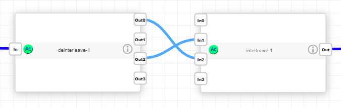

### Overview

This document outlines the specifications for an audio processing block that interleaves multiple input streams into a single output stream. Each input can be mono or multichannel, but all inputs must have the same number of channels. The output stream will contain all channels from all input streams.

Please note that the primary function of this algorithm is to amalgamate several input streams into one cohesive output stream. It is not designed to alter the interleaving format of the individual samples within the stream; such transformations are the responsibility of the “SFC” (Sample Format Converter) algorithm.

### Features

- **Multiple Inputs**: Accepts up to 4 several audio input streams by default. The source code is delivered so that it can be changed to any value thru the algorithm capabilities:
  - Inside the file called “audio_chain_interleave.c”
  - Set the number of supported inputs to a different value. See the field called

  ```
  .iosIn.nb =AUDIO_CAPABILITY_CHUNK_ONE_TWO_THREE_FOUR,
  ```

- **Uniform Channel Inputs**: Accepts multiple input streams with an equal number of channels. Compatible with both mono and multichannel formats, provided all inputs have the same channel count.
- **Interleaving**: Merges channels from all inputs into one interleaved output stream.
- **Format conversion**: Ability to change data format thanks to the “SFC” (Sample Format Converter) algorithm.

### Inputs/Outputs

- **Input Streams**: Multiple audio input streams.
- **Source Format**: The current format of the input audio samples is known thanks to the input pins that is aware of its own properties including data type and interleaving (see SFC documentation).
- **Target Format**: The desired format for the output audio samples is known thanks to the output pin that is aware of its own properties data type and interleaving (see SFC documentation).

#### Output

- **Interleaved Audio Stream**: A single audio output stream whose number of channels must be equal to sum of number of channels of input streams.

### Processing Steps

Note: this algorithm encapsulates the “SFC” (Sample Format Converter) for input & output management. Please refer to its documentation.

1. **Input Handling**: The block receives multiple audio input streams, each with the same number of channels.
2. **Interleaving** & **format conversion**:
- Channels from each input stream are interleaved one after the other. The process ensures that all the channels of each input are followed by all the channels of the next input, and so on.
- Interleave supports following format conversion:
  1. interleaved into non interleaved samples and vice versa.
  2. Can convert from any of this data type to any other within this list: FIXED16, FIXED32, FLOAT, G711.
  3. Can convert input PDM LSB into PDM MSB and vice versa.
- Interleave doesn’t support the following format conversion:
  1. It cannot convert PCM to PDM data nor PDM into PCM data (see PDM2PCM algorithm for that).
  2. It cannot convert sampling frequency.
1. **Output Generation**:
- The final output stream is produced with all channels from all inputs interleaved.

### Configuration Parameters

Apart for the format conversion, no parameter is needed, the block interleaves all the streams that are connected to the input pins.

The setting of the format conversion is handled by tuning the input & output pins according to the desired characteristics. Please refer to the SFC documentation.

## Linear mix

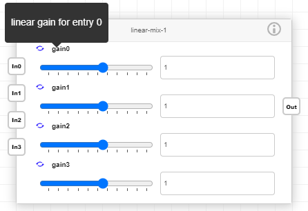

### Overview

The linear mixer “linear-mix” algorithm is the same algorithm as the “mix” but it has linear gain parameters instead of gains in decibels. The main advantage is to support negative gains allowing audio stream subtraction.

For more details, please refer to the “mix” algorithm dedicated documentation.

## MDRC

Multi-band Dynamic Range Compressor and limiter.

MRDC has several tabs: General, Band 0, Band 1, Band 2, Band 3, Band 4, Limiter tabs.

**General** tab

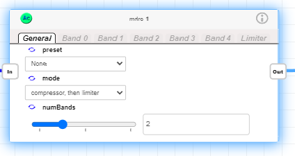

- **preset**: MDRC has today only one preset (“Bass-boost”).
- **mode**:
  - bypass: no compressor, no limiter.
  - compressor only
  - limiter only
  - compressor, then limiter: compressor first (1 to 5 sub-band(s)), then limiter
- **numBands**: number of sub-band(s); 1 to 5 sub-band(s)

**Band <n>** tab (n = 0 … 4), only band 0 … numBands-1 tabs are active.

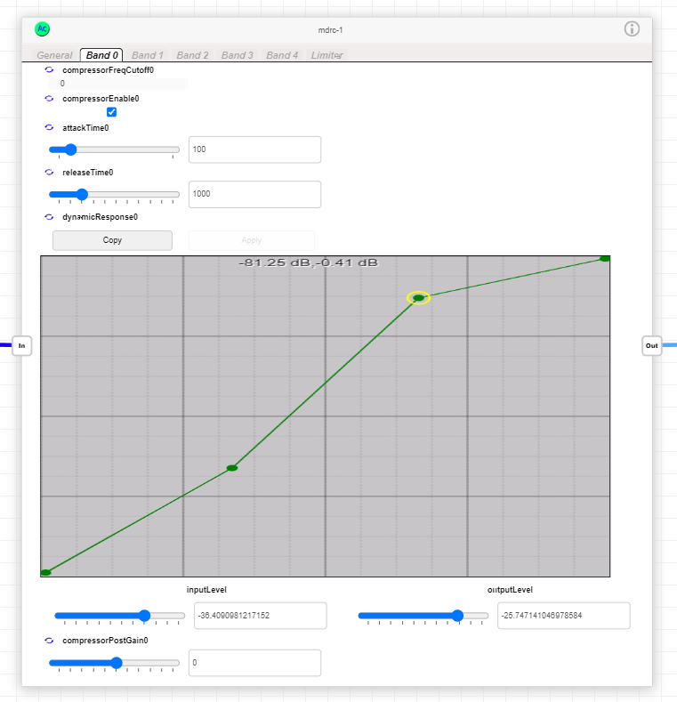

- **compressorFreqCutoff<n>**: lower frequency (Hz) of sub-band n; fixed value 0 Hz for n=0, user defined for n>0; higher frequency of sub-band n is equal to lower frequency of sub-band n+1; last sub-band (n=numBands-1) higher frequency is equal to sampling frequency / 2.
- **compressorEnable<n>**: enable or disable compressor for sub-band n.
- **attackTime<n>**: attack time in ms.
- **releaseTime<n>**: release time in ms
- **dynamicResponse<n>**: user sets compressor dynamic response curve (input level (dB) in abscissa, output level (dB) in ordinate) adding points in the graph; when a point is selected, user can set an accurate numerical value using inputLevel/outputLevel boxes below the graph.
- **compressorPostGain<n>**: output levels of dynamic response curve are negative in dB (maximum value is 0 dB); then a post gain is added to permit a bigger amplification of sub-band n.

### How to add a point in the dynamicResponse curve

Adding a point in the graph is done by shift click on the curve followed by a pointer move (i.e move the mouse).

Remark: the button permits to copy the dynamicResponse<n> graph as an image.

**Limiter** tab

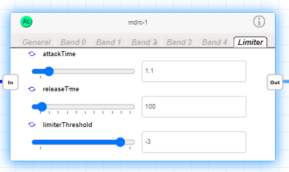

- **attackTime**: attack time in ms.
- **releaseTime**: release time in ms.
- **limiterThreshold**: threshold in dB above which limiter is applied.

## Mix

Mixer with API in dB. See linear-mix otherwise.

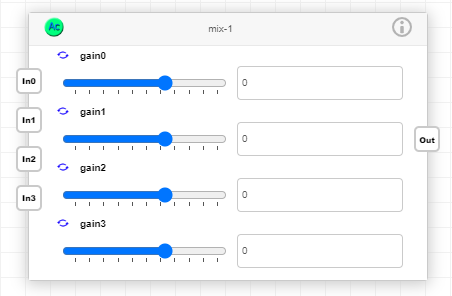

### Overview

This document outlines the design and functionality of the audio processing block intended for mixing multiple input streams into a single output stream. The block applies a given gain to the various inputs to create a composite audio output.

### Features

- **Multiple Inputs**: Accepts several audio input streams, however they must have the same number of channels.
- **Mixing**: Combines input streams into one output stream.
- **Gain Control**: Adjusts the volume of individual input streams before mixing.
- **Format conversion**: Ability to change data format.

### Inputs/Outputs

- **Input Streams**: Multiple audio streams.
- **Volume control**: A dedicated gain setting for every input.
- **Source Format**: The current format of the input audio samples is known thanks to the input pins that are aware of its own properties including data type and interleaving (see SFC documentation).
- **Target Format**: The desired format for the output audio samples is known thanks to the output pin that is aware of its own properties including data type and interleaving (see SFC documentation).

#### Output

- **Output Stream**: A single audio output stream that is the sum of all adjusted input streams.

### Processing Steps

1. **Input Handling**: Each input stream is received by the audio processing block.
2. **Gain control**:
   1. The gain parameter for each input is applied to adjust the volume level.
   2. Gain is converted from decibels to a linear scale before application.
3. **Summing:**
   1. The gain-adjusted input streams are summed together.
   2. The mixer ensures that the combined signal does not exceed the maximum; it clips signal.
4. **Output** Generation:
- The final mixed audio stream is delivered as the composite of all inputs with applied gains.

### Configuration Parameters

There are two types of parameters:

- Format information for conversion is retrieved from the pins so that it is up to the user to configure the wires according to his desire.
- The gain is a parameter which UI is provided as a tuning box and a slider.

## Mono2Stereo

Mono to stereo converter

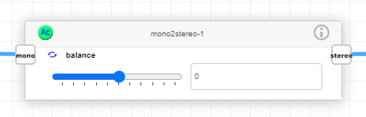

### Features

- **Input**: Accepts all PCM format, nbChannels must be equal to 1.
- **Output**: Accepts all PCM format, nbChannels must be equal to 2.
- **Format conversion**: Ability to change data format.

### Inputs/Outputs

- **Input Stream**: A single audio input mono stream.
- **balance**: balance between left & right output channels, between -1 (all left), 0 (duplicate input signal without gain modification into left & right channels) and +1 (all right)
  - left output channel gain = 1 if balance < 0, (1-balance) if balance > 0
  - right output channel gain = 1 if balance > 0, (1+balance) if balance < 0
- **Source Format**: The current format of the input audio samples is known thanks to the input pins that are aware of its own properties including data type and interleaving (see SFC documentation).
- **Target Format**: The desired format for the output audio samples is known thanks to the output pin that is aware of its own properties including data type and interleaving (see SFC documentation).

#### Output

- **Output Stream**: A single audio output stereo stream.

### Processing Steps

1. **Input Handling**: input stream is received by the audio processing block.
2. **Gain control**:
   1. Left & right output channels gain application according to balance as explained above.

### Configuration Parameters

There are two types of parameters:

- Format information for conversion is retrieved from the pins so that it is up to the user to configure the wires according to his desire.
- The balance is a parameter which UI is provided as a tuning box and a slider.

## NLMS

Normalized-LMS

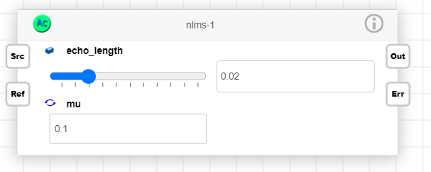

### Overview

This document describes the Normalized-LMS algorithm in **LiveTune**. This block is wrapping the CMSIS-DSP Normalized-LMS function. Please find the documentation here:

https://arm-software.github.io/CMSIS-DSP/latest/group__LMS__NORM.html

### Inputs/Outputs

- **Src**: input data.
- **Ref**: reference data
- **Echo length**: Maximal removable echo (in seconds). The number of coefficients is determined from this input: numTaps = echo_length * sampling_frequency;
- **Adaptation Step size**: It is the step size that controls filter coefficient updates; the biggest, the fastest convergence but the less accurate.

#### Output

- **Out**: output data:
  - It is the filtered input signal.
- **Err**: error data
  - It is the (Reference signal – filtered input signal).

## NR

Noise Reductor

NR algo is a stationary noise reductor; it tries to estimate SNR (Signal to Noise Ratio) by sub-band and apply a gain≤1 (or attenuation) in each sub-band depending on this SNR estimation and on a VAD estimation (also dependent on SNR of every sub-bands).

This algorithm assumes noise is stationary (slowly varying in time); it will be less efficient if noise is changing quickly (it will take some time to converge to a new noise model).

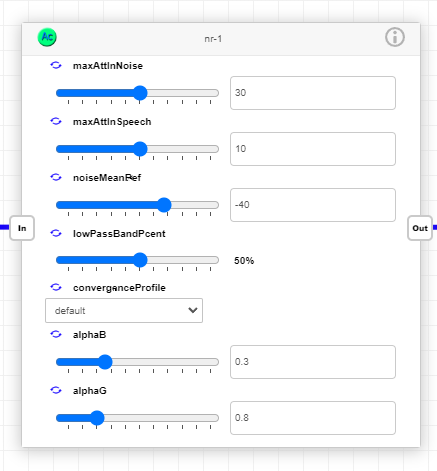

- **maxAttInNoise**: maximum attenuation (in dB) by sub-band when NR algo decides that this sub-band is noisy; the bigger, the more noise attenuation with higher risk of lower naturalness.
- **maxAttInSpeech**: maximum attenuation (in dB) by sub-band when NR algo decide that this sub-band is mainly speech (should be < maxAttInNoise).
- **noiseMeanRef**: reference average noise threshold (in dB) for min gain estimation; when average noise is below this threshold, NR computed attenuation is lowered to keep better naturalness.
- **lowPassBandPcent**: when signal is very noisy, NR may generate high frequency annoying artefacts (like whistles), this parameter permits in such cases to filter high frequencies and thus remove these artefacts; this parameter is expressed in percentage of the full-band signal (i.e. sampling frequency / 2); when signal is clean, the low-pass filter is not applied to preserve voice clarity.
- **convergenceProfile**: noise estimation speed.
  - default: good choice in most cases (for not too noisy signals).
  - fast: faster convergence at the risk of wrong noise estimation.
  - accurate : more accurate noise estimation but slower convergence.
  - user defined with alpha: convergence through alphaB & alphaG parameters below.
- **alphaB** and **alphaG** (only when convergenceProfile is set to **“**user defined with alpha**”**): these 2 parameters permit to define a per sub-band noise learning curve quite difficult to explain depending on SNR estimation and permitting to evaluate current SNR depending on previous SNR and new signal and thus to evaluate noise level of current sub-band. Lowering these alpha parameters accelerate noise estimation; user should try different values (separately for alphaB & alphaG) to understand impact on noise estimation speed and accuracy for its use-case.

## PDM2PCM

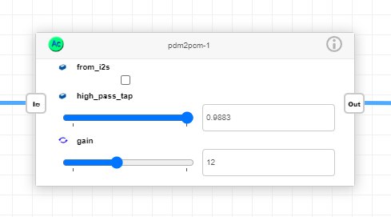

### Features

- **Input**: Accepts only PDM (LSB first or MSB first) format.
- **Output**: Accepts all PCM format
- **Format conversion**: Ability to change data format.

### Inputs/Outputs

- **Input Stream**: A single audio input stream.
- **from_i2s**: a checkbox telling if PDM data comes from I2S or not (if it comes from I2S, knowing that I2S data registers are 16 bits, in case of mono signal, changing the bit order on the I2S configuration will result in a temporal switch of two consecutive samples; thus the algo must know it to compensate this temporal switch)
- **high_pass_tap**: high pass coefficient (floating-point value), between 0 and 1 (the closest to 1, the steepest filter response; no high-pass filter if equal to 0)
- **gain**: gain in dB
- **Source Format**: The format for the input audio samples is known thanks to the input pin that is aware of its own properties.
- **Target Format**: The desired format for the output audio samples is known thanks to the output pin that is aware of its own properties.

#### Output

- **Output Stream**: A single audio output stream.

### Processing Steps

1. **Input Handling**: input stream is received by the audio processing block.
2. **pdm2pcm decoding**:
   1. decoding according to input vs output data types.

### Configuration Parameters

There are two types of parameters:

- Format information for conversion is retrieved from the pins so that it is up to the user to configure the wires according to his desire (input vs output data types).
- The parameters provided as a tuning box; see https://www.st.com/resource/en/user_manual/um2372-stm32cube-pdm2pcm-software-library-for-the-stm32f4f7h7-series-stmicroelectronics.pdf for further details

## Resample

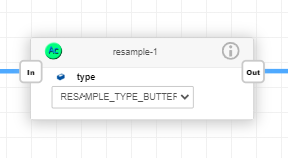

.

### Overview

The resample algorithm aim is to convert signal sampling frequency. It can do up or down sampling with integer or fractional resampling ratio.

### Inputs/Outputs

- **Input Stream**: Input audio stream.
- **Filtering Type**: Selection of IIR or FIR (see Features list section).
- **Source Sampling Frequency**: It is known thanks to the input pin that is aware of its own properties including data type and frequency (see following figure).
- **Target Sampling Frequency**: It is known thanks to the output pin that is aware of its own properties data type and frequency (see following figure).
- **Source Format**: The current format of the input audio samples is known thanks to the input pin that is aware of its own properties including data type and interleaving (see SFC documentation).
- **Target Format**: The desired format for the output audio samples is known thanks to the output pin that is aware of its own properties data type and interleaving (see SFC documentation).

#### Output

- **Output Stream**: A single audio output stream that is the input one at the request sampling frequency and formatted according to requested **Target Format**.

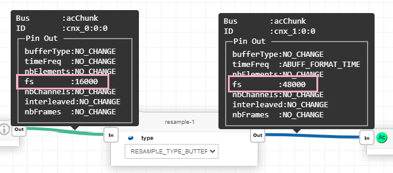

### Processing Information

The only resample configuration parameter is the filter type used for resampling; resample uses low-pass filters and several banks of filter with different filter design methods have been included in resample algo, each of these design methods have its pro & cons in terms of MHz/memory consumption (decreasing consumption order: Butterworth, Chebyshev1/Chebyshev2, elliptic), response curve (see https://en.wikibooks.org/wiki/Signals_and_Systems/Filter_Implementations and https://en.wikipedia.org/wiki/Elliptic_filter for more details).

### Configuration Parameters

There are two types of parameters:

- Format information for conversion is retrieved from the pins so that it is up to the user to configure the wires according to his desire:
  - Sampling frequencies
  - Interleaving.
  - Data types (fixed, float, etc….).
- The Filtering type is a parameter which UI is provided as a drop list.

## Route

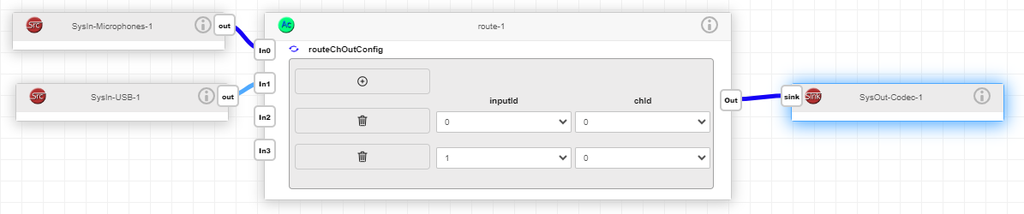

.

### Overview

This document outlines the design and functionality of the audio processing block intended for routing multiple input channels into a single output stream. The block selectively combines channels from various inputs to create a composite audio output.

### Features

- **Multiple Inputs**: Accepts up to 4 audio input streams.
- **Channel Selection**: Ability to choose specific channels from each input.
- **Format conversion**: Ability to change data format.

### Inputs/Outputs

- **Input Streams**: Multiple audio streams, each potentially with multiple channels.
- **Channel Select**: A set of parameters to select which channels to include in the output; called “routeChOutConfig”
- **Source Format**: The current format of the input audio samples is known thanks to the input pins that is aware of its own properties including data type and interleaving (see SFC documentation).
- **Target Format**: The desired format for the output audio samples is known thanks to the output pin that is aware of its own properties data type and interleaving (see SFC documentation).

#### Output

- **Composite Stream**: A single audio stream containing the chosen channels from the inputs.